# ROC curves and AUC

## Prognosis of subarachnoid hemorrhage

Dataframe `aSAH` in package `pROC` shows data from [this study](https://www.ncbi.nlm.nih.gov/pubmed/19760205)

```r
library(pROC); data(aSAH); head(aSAH)
```

```
   gos6 outcome gender age wfns s100b  ndka
29    5    Good Female  42    1  0.13  3.01
30    5    Good Female  37    1  0.14  8.54
31    5    Good Female  42    1  0.10  8.09
32    5    Good Female  27    1  0.04 10.42
33    1    Poor Female  42    3  0.13 17.40
34    1    Poor   Male  48    2  0.10 12.75
```

Brain injury biomarkers `ndka` and `s100b`, assessed at ICU admission, tend to be elevated in patients with poor `outcome` at 6 months.

Want to analize their accuracy to predict outcome.

## Data visualization

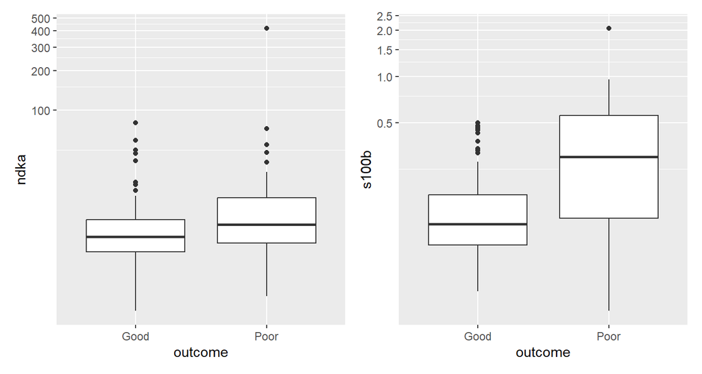

```r
library(dplyr); library(ggformula); library(patchwork)
p1 <- aSAH %>% gf_boxplot(ndka ~ outcome) %>% gf_refine(coord_transform(y = "log10"))
p2 <- aSAH %>% gf_boxplot(s100b ~ outcome) %>% gf_refine(coord_transform(y = "log10"))
p1 + p2
```

## ndka (ROC curve, AUC and 95% CI)

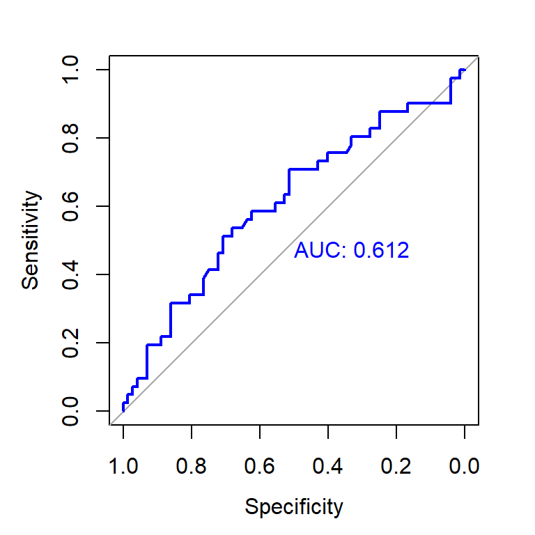

```r
roc1 <- roc(outcome ~ ndka, data = aSAH)
plot.roc(roc1, col="blue",
         print.auc = TRUE)
```

```r
auc(roc1)
```

```
Area under the curve: 0.612
```

```r
ci.auc(roc1)
```

```
95% CI: 0.5012-0.7227 (DeLong)
```

```r
set.seed(1)
ci.auc(roc1, method = "bootstrap")
```

```
95% CI: 0.5071-0.7219 (2000 stratified bootstrap replicates)
```

## s100b (ROC curve, AUC and 95% CI)

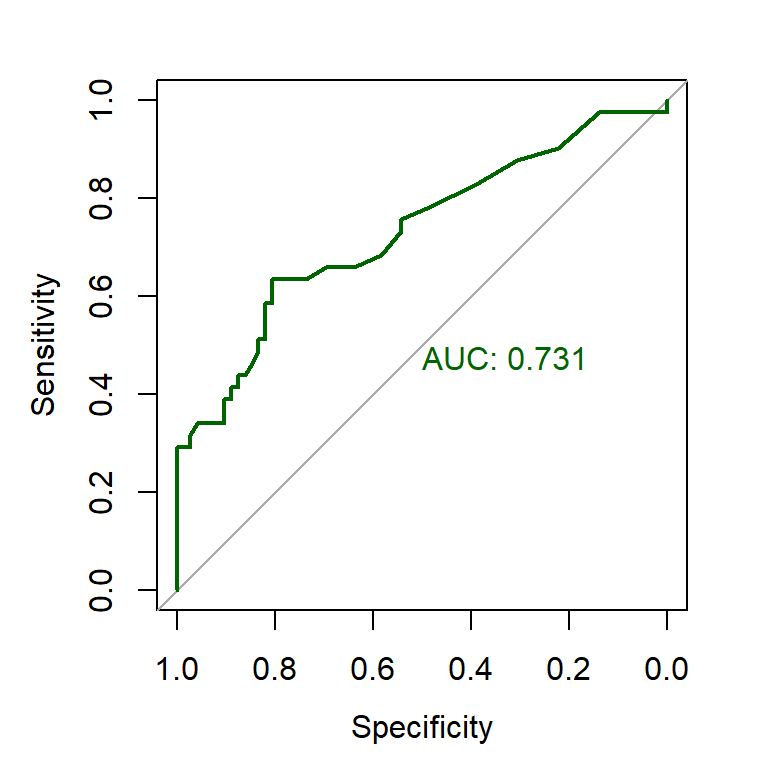

```r
roc2 <- roc(outcome ~ s100b, data = aSAH)
plot.roc(roc2, col="darkgreen",
         print.auc=TRUE)
```

```r
auc(roc2)
```

```
Area under the curve: 0.7314
```

```r
ci.auc(roc2)
```

```
95% CI: 0.6301-0.8326 (DeLong)
```

```r
set.seed(1)
ci.auc(roc2, method = "bootstrap")
```

```
95% CI: 0.6243-0.8269 (2000 stratified bootstrap replicates)
```

For more plotting options, see the help `?plot.roc`

## Comparing AUC’s of ROC curves: DeLong’s test

```r
roc.test(roc1, roc2)
```

```
    DeLong's test for two correlated ROC curves

data:  roc1 and roc2
Z = -1.3908, p-value = 0.1643
alternative hypothesis: true difference in AUC is not equal to 0
95 percent confidence interval:
 -0.28769174  0.04887061
sample estimates:
AUC of roc1 AUC of roc2
  0.6119580   0.7313686
```

No evidence of different accuracy (p = 0.164).

Uses normal approximation.

## Comparing AUC’s of ROC curves: bootstrap

```r
set.seed(1)                                   # for reproducibility
roc.test(roc1, roc2, method = "bootstrap")
```

```
    Bootstrap test for two correlated ROC curves

data:  roc1 and roc2
D = -1.4049, boot.n = 2000, boot.stratified = 1, p-value = 0.1601
alternative hypothesis: true difference in AUC is not equal to 0
sample estimates:
AUC of roc1 AUC of roc2
  0.6119580   0.7313686
```

No evidence of different accuracy (p = 0.160).

## Plotting both ROC curves

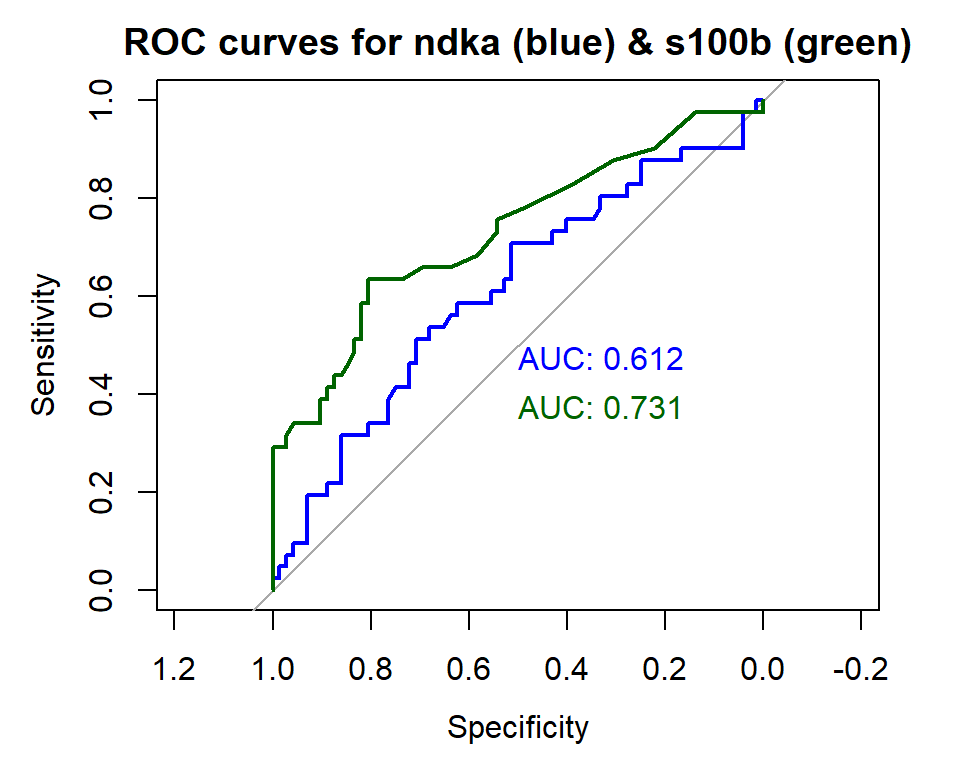

```r
plot.roc(roc1, col="blue", print.auc=TRUE,
         main = "ROC curves for ndka (blue) & s100b (green)")
plot.roc(roc2, col="darkgreen", print.auc=TRUE,
         add = TRUE, print.auc.x = 0.5, print.auc.y = 0.4)
```

## “Best” threshold (max. Youden index)

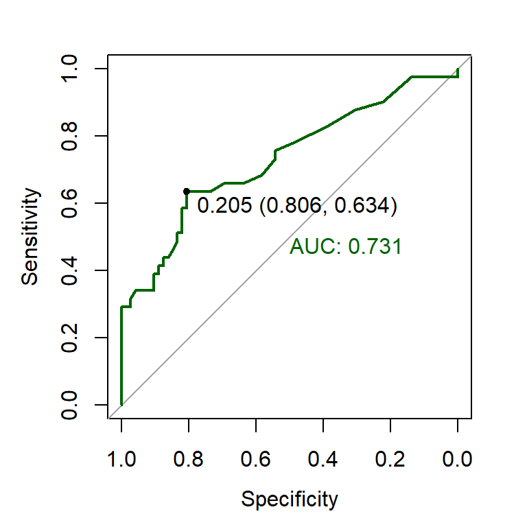

```r
plot.roc(roc2, col="darkgreen",
         print.auc=TRUE,
         print.thres = "best")
```

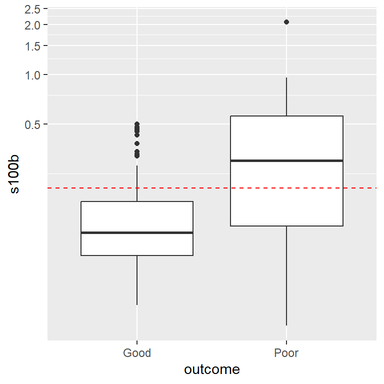

```r
aSAH %>% gf_boxplot(s100b ~ outcome) %>%
  gf_refine(coord_transform(y = "log10")) %>%
  gf_hline(yintercept = 0.205, lty=2, col = "red")
```

## Plotting ROC curves with ggplot2 graphic system

The `plot.roc()` function uses base R graphics

To produce a ggplot2 graphic, use `ggroc()`

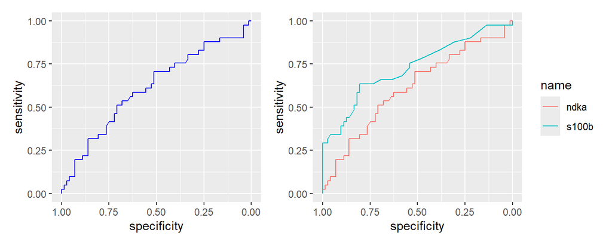

```r
plot1 <- ggroc(roc1, col = "blue")
plot2 <- ggroc(list(ndka=roc1, s100b=roc2))
plot1 + plot2
```

## A function for plotting 95% CI bands

Adapted from [here](https://rpubs.com/vguillem/465086).

```r
roc_with_ci <- function(obj) {
  ciobj <- ci.se(obj, specificities = seq(0, 1, l = 25))
  dat.ci <- data.frame(x = as.numeric(rownames(ciobj)),
                       lower = ciobj[, 1],
                       upper = ciobj[, 3])

  ggroc(obj, col = "blue") +
    theme_minimal() +
    geom_abline(
      slope = 1,
      intercept = 1,
      linetype = "dashed",
      alpha = 0.7,
      color = "darkgrey"
    ) + coord_equal() +
    geom_ribbon(
      data = dat.ci,
      aes(x = x, ymin = lower, ymax = upper),
      fill = "steelblue",
      alpha = 0.2
    ) + ggtitle(capture.output(obj$ci))
}
```

## A function for plotting 95% CI bands

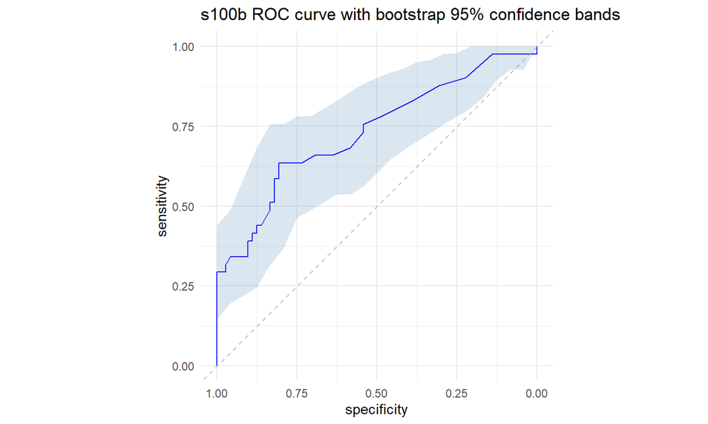

```r
roc_with_ci(roc2) %>%
  gf_labs(title = "s100b ROC curve with bootstrap 95% confidence bands")
```

## Exercise

Use the `aSAH` dataset in package `pROC` to analize the accuracy of `wfns` (World Federation of Neurological Surgeons) to predict poor outcome.

1. Plot the ROC curve of `wfns` along with those of `ndka` and `s100b`.
2. Compute AUC ROC and CI for all three markers, using appropriate method: DeLong’s or bootstrap?
3. Compare the AUC ROC of `wfns` with the other two markers using appropriate method: DeLong’s or bootstrap?
4. Plot the optimal threshold (maximizing the Youden index) in the ROC curve.

`wfns` is a factor. Start by converting to a numeric variable with `as.numeric()`:

```r
library(pROC); data(aSAH)
aSAH$wfns <- as.numeric(aSAH$wfns)
```